# CCHA site assessments

MW Beck

06 February, 2022

```r
knitr::opts_chunk$set(echo = TRUE, warning = F, message = F)

box::use(
  here[...],
  ggplot2[...],
  tidyr[...],
  dplyr[...],
  ggridges[...],
  reactable[...],
  lubridate[ymd, year],
  stringr[str_wrap],
  forcats[fct_reorder2],
  htmltools[h5],
  htmlwidgets[prependContent]
)

source(here('R/funcs.R'))

load(file = here('data/vegdat.RData'))
load(file = here('data/treedat.RData'))

thm <- theme_minimal(base_size = 14) +
  theme(
    panel.grid.minor = element_blank()
  )

# test args
site <- 'Big Bend - TECO'
sp <- 'Avicennia germinans'
```

Plot showing number of times a zone was identified across transects, dates.

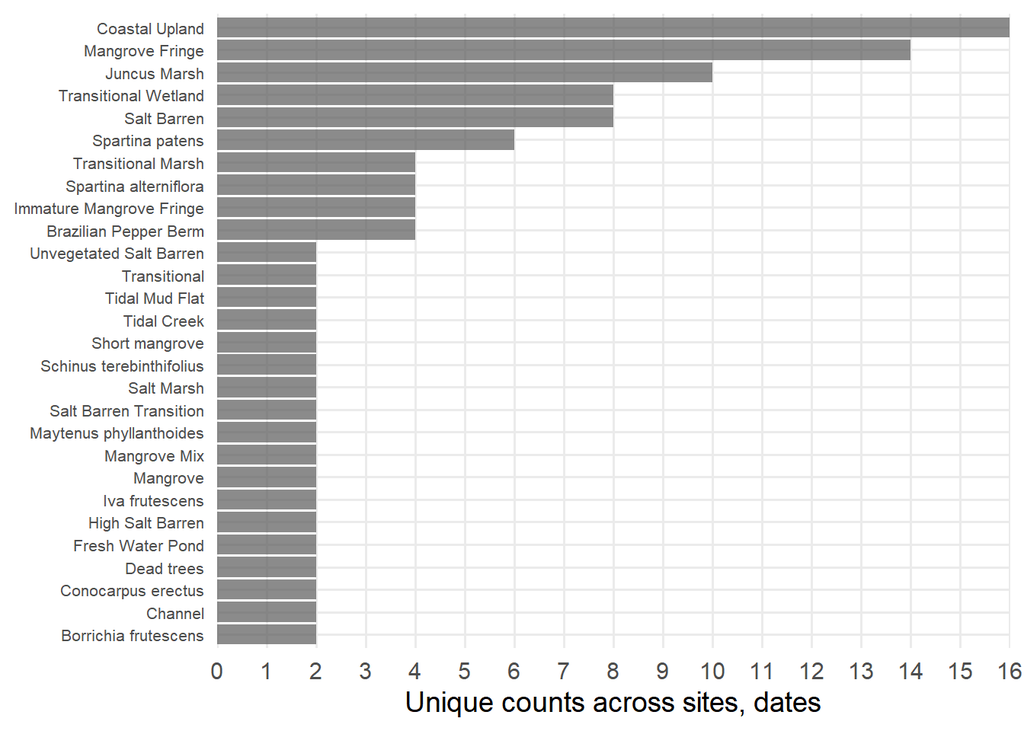

```r
zonecnt_plo(vegdat, thm)
```

Plot showing total distance zone was recorded across transect, dates.

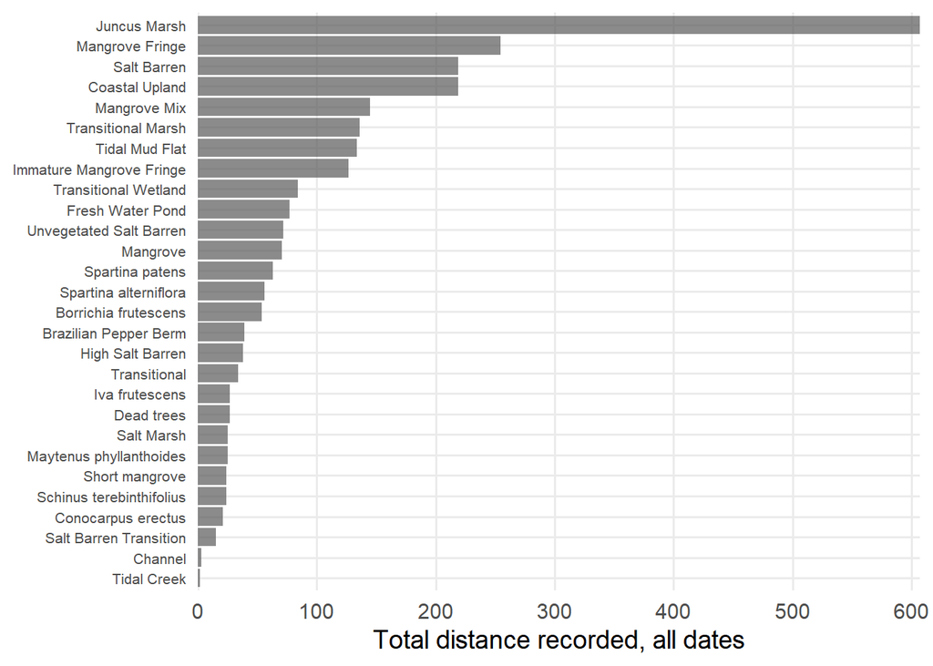

```r
zonedst_plo(vegdat, thm)
```

An example showing zones for two sample dates at one site.

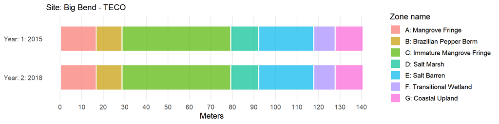

```r
sitezonedst_plo1(vegdat, site = site, zonefct = NULL, thm = thm)
```

To evaluate simple changes in zones over time, an estimate of total distance per zone between time points could be evaluated. This is also very similar to the previous plot.

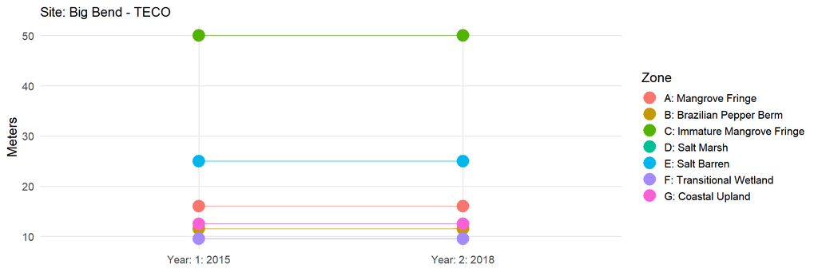

```r
sitezonedst_plo2(vegdat, site = site, zonefct = NULL, thm = thm)
```

The same site, but showing species data along the transect.

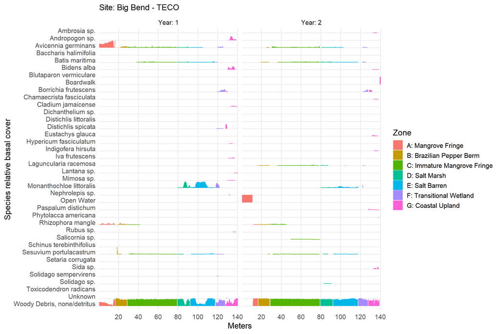

```r
sitezonedst_plo3(vegdat, site, thm = thm)
```

An evaluation of a single species across all sites, can be shown as frequency occurrence across the transect or mean percent basal cover. This example shows frequency occurrence of *Avicennia germinans*.

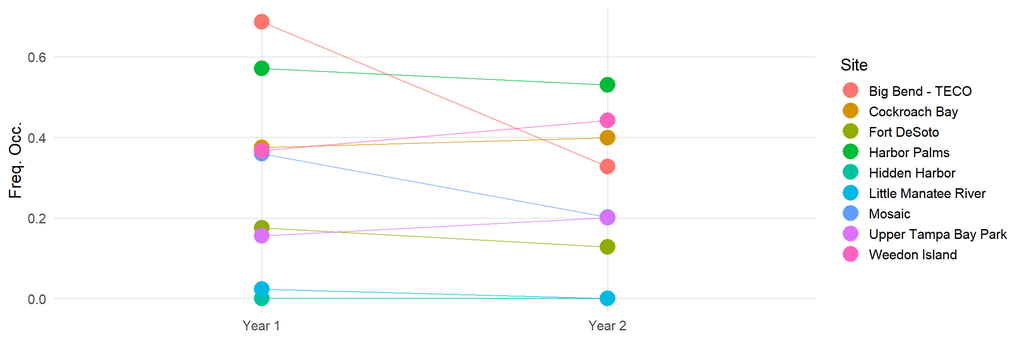

```r
sppsum_plo(vegdat, sp, var = 'fo', thm = thm)
```

And now average percent basal cover.

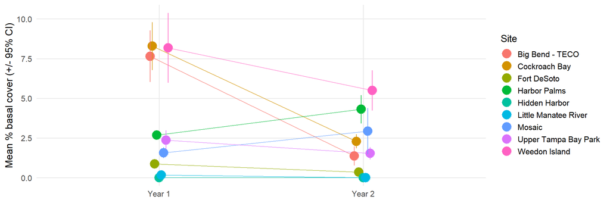

```r
sppsum_plo(vegdat, sp, var = 'cover', thm = thm)
```

A table of species frequency occurrence by zone, over time:

```r
sitezonesum_tab(vegdat, site = site)
```

| Zone | Species | Year 1 | Year 2 |
| --- | --- | --- | --- |
| A: Mangrove Fringe | Avicennia germinans | 1 | 0.0303030303030303 |
| A: Mangrove Fringe | Laguncularia racemosa | NA | 0.0606060606060606 |
| A: Mangrove Fringe | Open Water | NA | 0.666666666666667 |
| A: Mangrove Fringe | Rhizophora mangle | 0.909090909090909 | 0.303030303030303 |
| A: Mangrove Fringe | Woody Debris, none/detritus | 1 | 0.333333333333333 |
| B: Brazilian Pepper Berm | Avicennia germinans | 0.666666666666667 | 0.125 |
| B: Brazilian Pepper Berm | Batis maritima | 0.0416666666666667 | 0.0833333333333333 |
| B: Brazilian Pepper Berm | Blutaparon vermiculare | NA | 0.0416666666666667 |
| B: Brazilian Pepper Berm | Laguncularia racemosa | NA | 0.208333333333333 |
| B: Brazilian Pepper Berm | Paspalum distichum | NA | 0.0416666666666667 |

[output cut: 65 more lines]

Same thing but as percent basal cover.

```r
sitezonesum_tab(vegdat, site = site, var = 'cover')
```

| Zone | Species | Year 1 | Year 2 |
| --- | --- | --- | --- |
| A: Mangrove Fringe | Avicennia germinans | 0.572778787878788 | 0.0242424242424242 |
| A: Mangrove Fringe | Laguncularia racemosa | NA | 0.00121212121212121 |
| A: Mangrove Fringe | Open Water | NA | 0.666666666666667 |
| A: Mangrove Fringe | Rhizophora mangle | 0.0778787878787879 | 0.00787878787878788 |
| A: Mangrove Fringe | Woody Debris, none/detritus | 0.339067647058824 | 0.3 |
| B: Brazilian Pepper Berm | Avicennia germinans | 0.0630769230769231 | 0.0025 |
| B: Brazilian Pepper Berm | Batis maritima | 0.000416666666666667 | 0.000833333333333333 |
| B: Brazilian Pepper Berm | Blutaparon vermiculare | NA | 0.00208333333333333 |
| B: Brazilian Pepper Berm | Laguncularia racemosa | NA | 0.00541666666666667 |
| B: Brazilian Pepper Berm | Paspalum distichum | NA | 0.000833333333333333 |

[output cut: 65 more lines]

A plot of sum of percent basal cover by arbitrary meter markings, top species, and across zones.

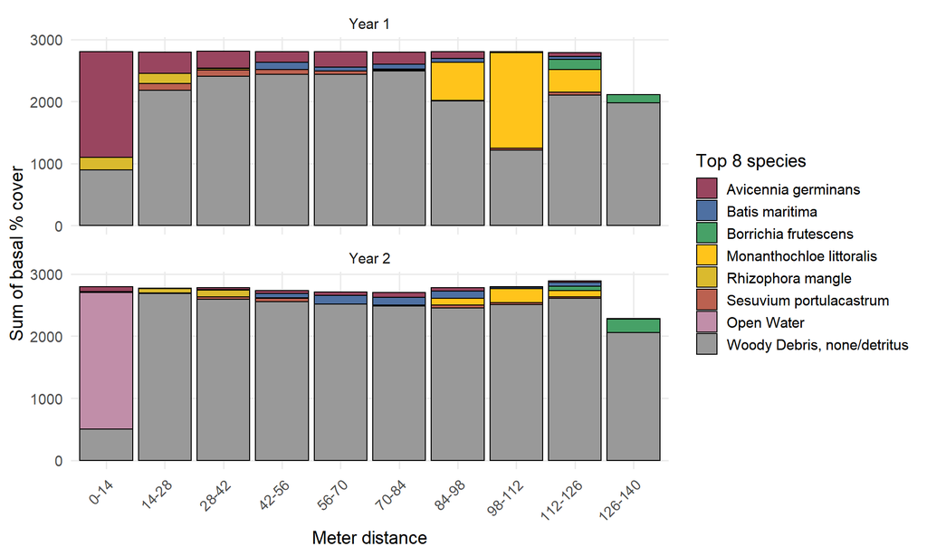

```r
sitesum_plo(vegdat, site, delim = 10, vegsel = 8, var = 'cover', thm = thm, delimtyp = 'Number')
```

A plot of sum of percent basal cover by arbitrary meter markings, top species, and for select zones.

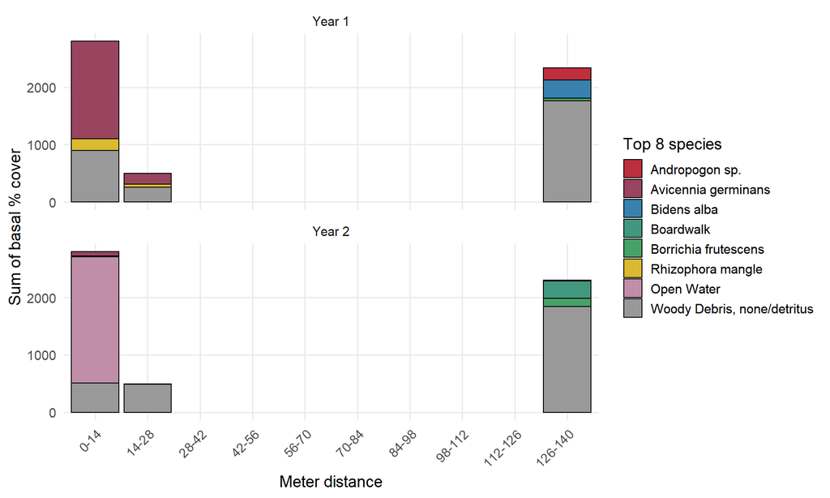

```r
sitesum_plo(vegdat, site, delim = 10, vegsel = 8, var = 'cover', zonefct = c('A: Mangrove Fringe', 'G: Coastal Upland'), thm = thm,  delimtyp = 'Number')
```

Tabular summary of tree data by site, species.

```r
treesum_tab(treedat, site = site, byspecies = T, var = 'trees_ha')
```

##### Big Bend - TECO, Absolute species density (trees/ha)

| Zone | Species | Year 1 | Year 2 |
| --- | --- | --- | --- |
| A: Mangrove Fringe | Avicennia germinans | 3768.4392980218 | 4409.56058484304 |
| A: Mangrove Fringe | Laguncularia racemosa | 1256.14643267393 | 1102.39014621076 |
| A: Mangrove Fringe | Rhizophora mangle | NA | 1102.39014621076 |
| B: Brazilian Pepper Berm | Avicennia germinans | 651.716619712718 | 1385.94690822953 |
| B: Brazilian Pepper Berm | Rhizophora mangle | 93.102374244674 | 461.982302743177 |
| B: Brazilian Pepper Berm | Schinus terebinthifolius | 372.409496978696 | 692.973454114766 |
| B: Brazilian Pepper Berm | Laguncularia racemosa | NA | 230.991151371589 |
| C: Mangrove Fringe | Avicennia germinans | 4550.37939621084 | 3027.15759441693 |
| C: Mangrove Fringe | Laguncularia racemosa | NA | 1009.05253147231 |
| G: Coastal Upland | Avicennia germinans | 129.434691524143 | 131.366958935393 |

[output cut: 6 more lines]

Same table as above, but aggregated across species.

```r
treesum_tab(treedat, site = site, byspecies = F, var = 'trees_ha')
```

##### Big Bend - TECO, Absolute species density (trees/ha)

| Zone | Year 1 | Year 2 |
| --- | --- | --- |
| A: Mangrove Fringe | 5024.58573069573 | 6614.34087726457 |
| B: Brazilian Pepper Berm | 1117.22849093609 | 2771.89381645906 |
| C: Mangrove Fringe | 4550.37939621084 | 4036.21012588923 |
| G: Coastal Upland | 517.738766096572 | 315.280701444943 |

Tree summary plot by site, species.

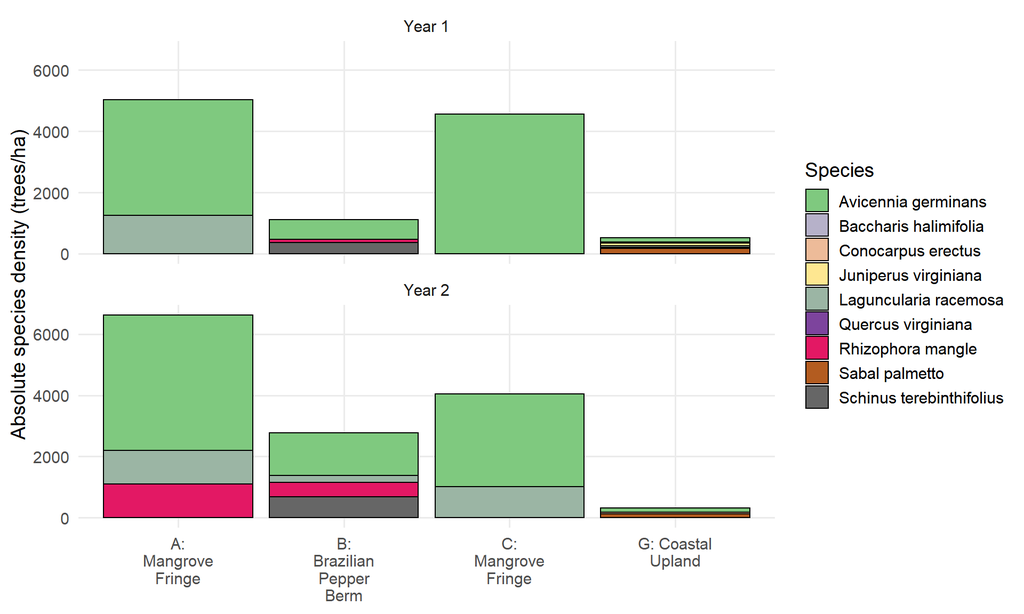

```r
treesum_plo(treedat, site = site, byspecies = T, var = 'trees_ha', thm = thm)
```

Tree summary plot, but aggregated across species.

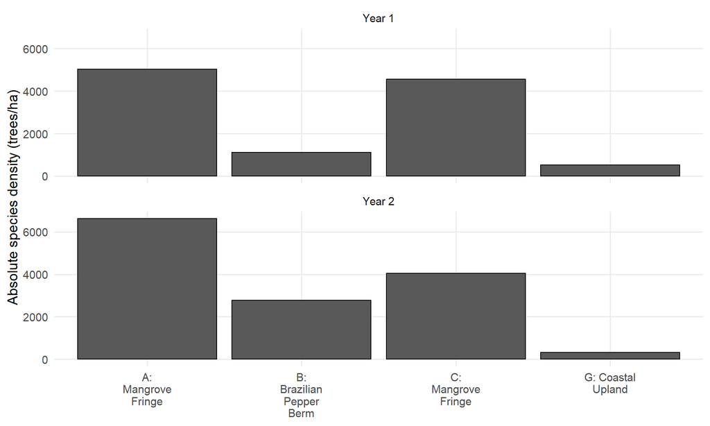

```r
treesum_plo(treedat, site = site, byspecies = F, var = 'trees_ha', thm = thm)
```